# Meat flavor analysis

2025-01-06

# Data processing & exploratie

Deze sectie heeft als doel de compositionele data voor te bereiden voor log-ratio transformaties. Hiervoor worden alle parts (groepen in een compositie) van de compositie bekeken, geïnterpreteerd en omgezet in betere structuur voor verdere analyses. Daarna wordt de data geanalyseerd op aanwezigheid van nulwaardes aangezien deze problematisch zijn in log-ratio transformaties, en besproken hoe ermee omgegaan zal worden. Ten slotte worden outliers gedecteerd, en indien nodig verwijderd zodat we eindigen met een dataset geschikt voor log-ratio transformaties

## Data inladen

Alle nodige packages worden hier ingeladen.

```r
library(DBI)
library(RSQLite)
library(stats)
library(tidyverse)
library(compositions)
library(rlang)
library(MASS)
library(ggplot2)
library(ggfortify)
library(dplyr)
library(tidyr)
```

De database die hier gebruikt wordt is opgebouwd door in patenten (met als onderwerp ‘synthetiseren van artificiële vleessmaken’) op zoek te gaan voorbeeldrecepten die een bepaalde vleessmaak nabootsen. Als alle recepten voorgesteld zouden worden als een compositie van alle ingrediënten zullen er later problemen ontstaan tijdens de analyse aangezien het aantal parts te groot is: 71. Hierdoor worden alle ingrediënten samengevat door hun chemische groepen zoals suikers, aminozuren, ribonucleotides, etc. en worden recepten gezien als een compositie hiervan. Deze beslissing wordt ook gemotiveerd door de informatie in de patenten aangezien in de beschrijving van de synthetische vleessmaak enkel over chemische groepen wordt gesproken, en enkel in recepten specifieke ingrediënten worden gebruikt. Vaak zijn deze ingrediënten dan ook de meest economische optie binnenin de categorie, en verliest het veralgemenen van ingrediënten naar chemische groepen geen relevante informatie voor het synthetiseren van vleessmaken.

```r
db <- dbConnect(RSQLite::SQLite(),
                "C:/Users/bramd_finhsgu/OneDrive - UGent/Thesis/Thesis_bestanden/recipes9.db")

recipes            <- dbReadTable(db, "recipes")
chemical_groups    <- dbReadTable(db, "chemical_groups")
ingredients        <- dbReadTable(db, "ingredients")
recipe_ingredients <- dbReadTable(db, "recipe_ingredients")


data_grouped <- recipe_ingredients %>%
  left_join(ingredients, by = c("ingredient_id" = "id")) %>%  # Voeg ingrediënten toe
  left_join(chemical_groups, by = c("chemical_group_id" = "id")) %>%  # Voeg chemische groepen toe
  group_by(recipe_id, group_name) %>%
  summarise(total_quantity = sum(total_quantity, na.rm = TRUE), .groups = "drop") %>%
  pivot_wider(names_from = group_name, values_from = total_quantity, values_fill = 0) %>%
  # LET OP: we gebruiken expliciet dplyr::select(...) om conflicts te vermijden
  left_join(
    recipes %>% dplyr::select(id, recipe_name, cooking_time, temperature, flavor_label, preparation),
    by = c("recipe_id" = "id")
  ) %>%
  # Ook hier expliciet dplyr::select(...):
  dplyr::select(recipe_name, cooking_time, temperature, flavor_label, preparation, everything(), -recipe_id)

print("Header van data_grouped:")
```

```
## [1] "Header van data_grouped:"
```

```r
print(head(data_grouped))
```

```
## # A tibble: 6 × 15
##   recipe_name cooking_time temperature flavor_label preparation Aminozuren
##   <chr>              <dbl>       <int> <chr>        <chr>            <dbl>
## 1 Example 1              7          85 chicken      boiled              40
## 2 Example 2              5          90 chicken      boiled              40
## 3 Example 3             10          60 chicken      boiled              30
## 4 Example 4              7          85 chicken      boiled              40
## 5 Example 5              5          90 chicken      boiled              40
## 6 Example 6             10          60 chicken      boiled              30
## # ℹ 9 more variables: Ribonucleotides <dbl>, Smaakenhancer <dbl>, Suiker <dbl>,
## #   Vetten <dbl>, Water <dbl>, Zuren <dbl>,
## #   `Zwavel bevattende aminozuren` <dbl>, extra <dbl>, Volatiles <dbl>
```

## Nullen controleren

De aanwezigheid van nullen in compositionele data is een probleem aangezien het niet compatibel is met log-ratio transformaties. In compositionele data worden er 2 soorten nullen onderscheiden: rounded zeroes & structural zeroes. Rounded zeroes zijn de nullen die door meetfouten of processfouten niet zijn opgenomen of verwerkt, maar er wordt wel een waarde verwacht, structural zeroes zijn dan de nullen die effectief een nul representeren. Er bestaan verschillende manieren om om te gaan met rounded zeroes zoals imputatie, KNN, Bayesian-multiplicative replacement strategy, etc. aangezien er een waarde verwacht wordt en de nul vervangen kan worden. Voor structural zeroes gaat dit helaas niet zo makkelijk aangezien de 0 verwacht wordt en betekenis heeft. De nullen in onze data zijn structurele nullen door de aard van recepten, een afwezigheid van een component betekent ook effectief dat deze component afwezig hoort te zijn.

```r
excluded_columns <- c("recipe_name", "cooking_time", "temperature", "preparation", "flavor_label")
percent_nulls <- data_grouped %>%
  summarise(across(-all_of(excluded_columns), ~ mean(. == 0, na.rm = TRUE) * 100))

result_table <- data.frame(
  Kolomnaam = colnames(percent_nulls),
  Percentage_Nullen = as.numeric(percent_nulls[1, ])
)
print(result_table)
```

```
##                       Kolomnaam Percentage_Nullen
## 1                    Aminozuren          2.439024
## 2               Ribonucleotides         32.520325
## 3                 Smaakenhancer         49.593496
## 4                        Suiker         12.195122
## 5                        Vetten         55.284553
## 6                         Water         29.268293
## 7                         Zuren         92.682927
## 8  Zwavel bevattende aminozuren         19.512195
## 9                         extra         80.487805
## 10                    Volatiles         95.121951
```

## Outlier detectie

Outlier detectie voor compositionele data met strcuturele nullen: Templ, M., Hron, K., & Filzmoser, P. (2016). Exploratory tools for outlier detection in compositional data with structural zeros. Journal of Applied Statistics, 44(4), 734–752. https://doi.org/10.1080/02664763.2016.1182135 *Nog geen functies hiervoor, voor deze workflow te integreren in een functie -> nadenken of deze detectie wel geschikt is als de nulwaarden toch geïmputeerd zullen worden. Het klinkt veelbelovend, maar potentieel overbodig als de nullen toch geïmputeerd worden.*

Indien we verder werken met de imputaties en gefilterde dataset: Mahalanobis-afstanden is de standaard om outliers te detecteren in compositionele data *normaliteit

```r
data_preprocessed <- data_grouped %>%
  dplyr::select(-c(recipe_name, cooking_time, temperature, flavor_label, preparation)) %>%
  mutate(Carrier = Water + Vetten) %>%
  dplyr::select(-c(Water, Vetten, Zuren, extra, Volatiles, Smaakenhancer))

epsilon <- 1e-5
data_no_zeros <- data_preprocessed %>%
  mutate(across(everything(), ~ ifelse(. == 0, epsilon, .)))

data_normalized <- data_no_zeros %>%
  mutate(across(everything(), ~ . / rowSums(data_no_zeros, na.rm = TRUE)))

data_ilr <- data_normalized %>%
  compositions::ilr()

mahal_distances <- mahalanobis(data_ilr, colMeans(data_ilr, na.rm = TRUE), cov(data_ilr, use = "pairwise.complete.obs"))
threshold <- qchisq(0.975, df = ncol(data_ilr))
outliers <- which(mahal_distances > threshold)

list_of_outliers <- outliers
print("Outliers gevonden op basis van Mahalanobis-afstanden:")
```

```
## [1] "Outliers gevonden op basis van Mahalanobis-afstanden:"
```

```r
print(list_of_outliers)
```

```
## [1]  15  16  17 102 106 120 121 123
```

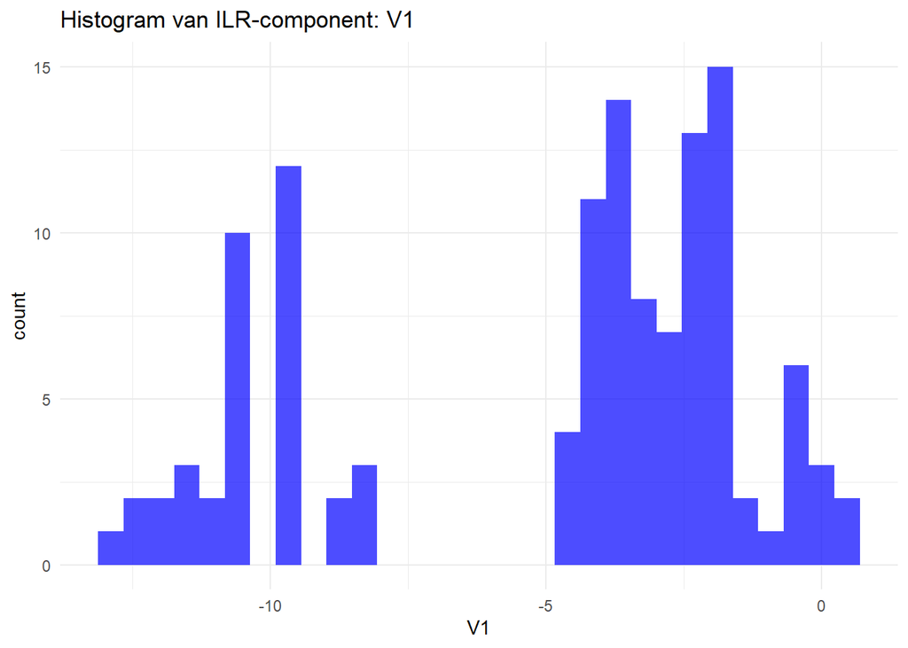

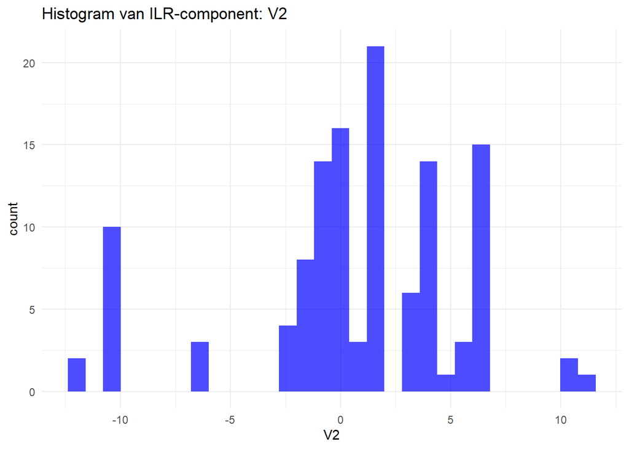

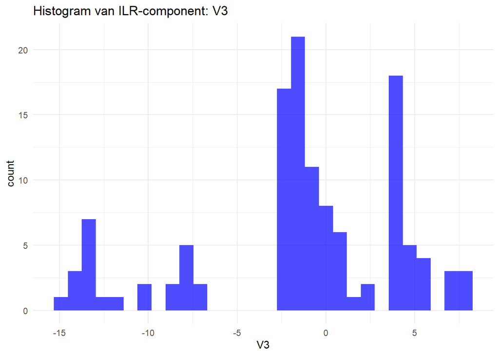

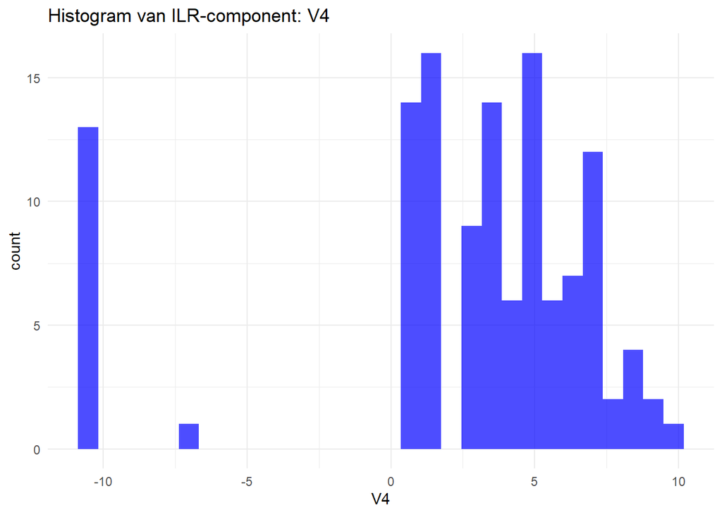

```r
ilr_df <- as.data.frame(data_ilr)
for (i in seq_along(ilr_df)) {
  col_name <- colnames(ilr_df)[i]
  plot <- ggplot(ilr_df, aes(x = !!sym(col_name))) +
    geom_histogram(bins = 30, fill = "blue", alpha = 0.7) +
    labs(title = paste("Histogram van ILR-component:", col_name)) +
    theme_minimal()
  print(plot)
}
```